# Probability and Statistics

# Lab Assignment 1: Naive Bayes Classifier

### *Dmytro Batko, Yelyzaveta Zarichanska, Mykyta Ishchenko*

## Introduction

During the past three weeks, you learned a couple of essential notions and theorems, and one of the most important among them is the *Bayes theorem*.

One of its applications is **Naive Bayes classifier**, which is a probabilistic classifier whose aim is to determine which class some observation probably belongs to by using the Bayes formula:
$$\mathsf{P}(\mathrm{class}\mid
\mathrm{observation})=\frac{\mathsf{P}(\mathrm{observation}\mid\mathrm{class})\mathsf{P}(\mathrm{class})}{\mathsf{P}(\mathrm{observation})}$$

Under the strong independence assumption, one can calculate $\mathsf{P}(\mathrm{observation} \mid \mathrm{class})$ as
$$\mathsf{P}(\mathrm{observation}) =
\prod_{i=1}^{n} \mathsf{P}(\mathrm{feature}_i), \qquad
\mathsf{P}(\mathrm{observation} \mid \mathrm{class}) = \prod_{i=1}^{n}
\mathsf{P}(\mathrm{feature}_i \mid \mathrm{class}),$$
where $n$ is the total number of features describing a given observation. Thus, $\mathsf{P}(\mathrm{class}|\mathrm{observation})$ now can be calculated as

$$\mathsf{P}(\mathrm{class} \mid
\mathrm{\mathrm{observation}}) = \mathsf{P}(\mathrm{class})\times
\prod_{i=1}^{n}\frac{\mathsf{P}(\mathrm{feature}_i\mid
\mathrm{class})}{\mathsf{P}(\mathrm{feature}_i)}\tag{1}$$

All the terms on the right-hand side can be estimated from the data as respective relative frequencies;  
see [this site](https://monkeylearn.com/blog/practical-explanation-naive-bayes-classifier/) for more detailed explanations.

## Data description

There are 5 datasets uploaded on the cms.

To determine your variant, take your team number from the list of teams on cms and take *mod 5* - this is the number of your data set.

- **0 - authors** This data set consists of citations of three famous writers: Edgar Alan Poe, Mary Wollstonecraft Shelley and HP Lovecraft. The task with this data set is to classify a piece of text with the author who was more likely to write it.
- **1 - discrimination** This data set consists of tweets that have discriminatory (sexism or racism) messages or of tweets that are of neutral mood. The task is to determine whether a given tweet has discriminatory mood or does not.
- **2 - fake news** This data set contains data of American news: a headline and an abstract of the article. Each piece of news is classified as fake or credible. The task is to classify the news from test.csv as credible or fake.
- **3 - sentiment** All the text messages contained in this data set are labeled with three sentiments: positive, neutral or negative. The task is to classify some text message as the one of positive mood, negative or neutral.
- **4 - spam** This last data set contains SMS messages classified as spam or non-spam (ham in the data set). The task is to determine whether a given message is spam or non-spam.

Each data set consists of two files: *train.csv* and *test.csv*. The first one you will need find the probabilities distributions for each of the features, while the second one is needed for checking how well your classifier works.

```r
# here goes a list of recommended libraries,
# though you may install other ones if they are needed
library(tidytext)
library(readr)
library(dplyr)
```

```r
library(ggplot2)
library(tm)
library(stringr)
library(wordcloud)
```

## Instructions

- The first step is data pre-processing, which includes removing punctuation marks and stop words
- represent each message as a bag-of-words
- using the training set, calculate all the conditional probabilities in formula (1)
- use those to predict classes for messages in the test set
- evaluate effectiveness of the classifier by calculating the corresponding metrics
- shortly summarize your work
- do not forget to submit both the (compiled) Rmd source file and the .html output

### Data pre-processing

- Read the *.csv* data files.
- Сlear your data from punctuation or other unneeded symbols.
- Clear you data from stop words. You don’t want words as is, and, or etc. to affect your probabilities distributions, so it is a wise decision to get rid of them. Find list of stop words in the cms under the lab task.
- Represent each test message as its bag-of-words. Here: https://machinelearningmastery.com/gentle-introduction-bag-words-model/ you can find general introduction to the bag-of-words model and examples on to create it.
- It is highly recommended to get familiar with R dataframes, it would make the work much easier to do.
- Useful links:
  - https://steviep42.github.io/webscraping/book/bagofwords.html#tidytext - example of using *tidytext* to count frequencies of the words.
  - Basics of Text Mining in R: http://rstudio-pubs-static.s3.amazonaws.com/256588_57b585da6c054349825cba46685d8464.html . Note that it also includes an example on how to create a bag of words from your text document.

```r
test_path <- "data/1-discrimination/test.csv"
train_path <- "data/1-discrimination/train.csv"

stop_words <- read_file("stop_words.txt")
# https://stackoverflow.com/questions/27195912/why-does-strsplit-return-a-list
splitted_stop_words <- strsplit(stop_words, split='\n')
splitted_stop_words <- splitted_stop_words[[1]]

train <- read.csv(file = train_path)
test <- read.csv(file = test_path, stringsAsFactors = FALSE)
```

### Data visualization

Each time you work with some data, you need to understand it before you start processing it. R has very powerful tools to make nice plots and visualization. Show what are the most common words for negative and positive examples as a histogram, word cloud etc. Be creative!

## Classifier implementation

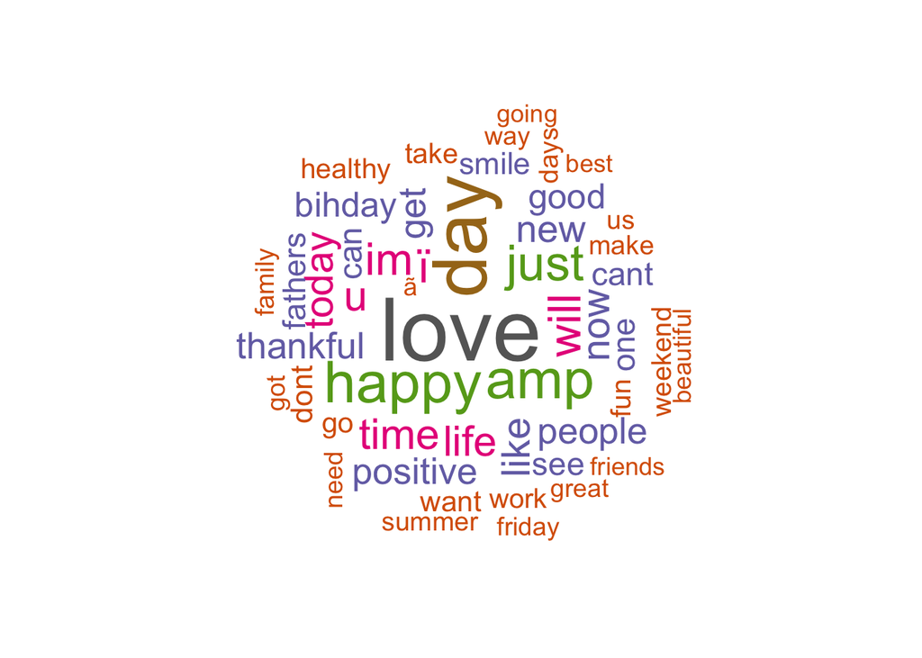

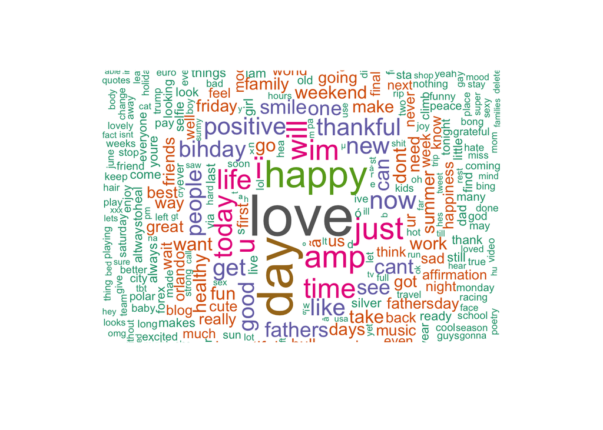

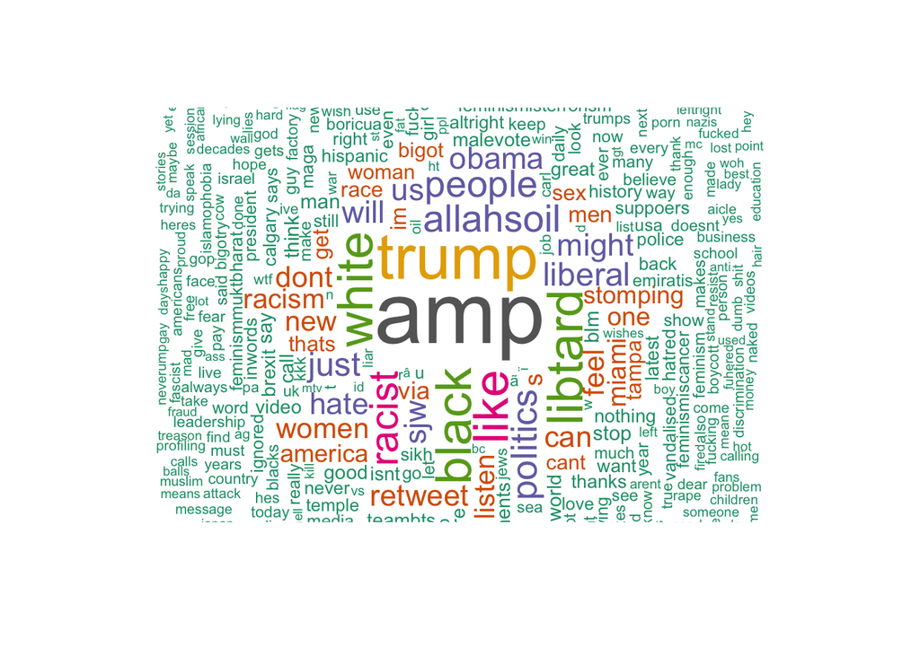

```r
naiveBayes <- setRefClass("naiveBayes",

       # here it would be wise to have some vars to store intermediate result
       # frequency dict etc. Though pay attention to bag of wards!
       fields = list(
         text = "data.frame",
         dataframe_with_gen_freq = "data.frame",
         for_neutral = "data.frame",
         tidy_text_neutral = "data.frame",
         for_discrim = "data.frame",
         tidy_text_discrim = "data.frame",
         sum_of_elements_neutral = "double",
         sum_of_elements_discrim = "double",
         sum_of_elem_without_rep = "double"
       ),
       methods = list(
                    # prepare your training data as X - bag of words for each of your
                    # messages and corresponding label for the message encoded as 0 or 1
                    # (binary classification task)
                    fit = function()
                    {
                        text <<- data.frame(label = train$label, tweet = train$tweet)

                        text <<- mutate(text, tweet = gsub(x = tweet, pattern = "user|[0-9]+|[[:punct:]]|â|ð", replacement = ""))

                        tidy_text <- unnest_tokens(text, 'splitted', 'tweet', token="words") %>%
                                     filter(!splitted %in% splitted_stop_words)
                        dataframe_with_gen_freq <<- tidy_text %>% count(splitted, sort = "True")
                        #cloud of words
                        wordcloud(words = dataframe_with_gen_freq$splitted, freq = dataframe_with_gen_freq$n, min.freq = 1, max.words=50, random.order=FALSE, rot.per=0.35, colors=brewer.pal(8, "Dark2"))

                        for_neutral <<- filter(text, label=="neutral")
                        tidy_text_neutral <<- unnest_tokens(for_neutral, 'splitted', 'tweet', token="words") %>%
                                     filter(!splitted %in% splitted_stop_words)
                        tidy_text_neutral <<- tidy_text_neutral %>% count(splitted, sort = "True")
                        #cloud of words
                        wordcloud(words = tidy_text_neutral$splitted, freq = tidy_text_neutral$n, min.freq = 1, max.words=550, random.order=FALSE, rot.per=0.35, colors=brewer.pal(8, "Dark2"))

                        for_discrim <<- filter(text, label=="discrim")
                        tidy_text_discrim <<- unnest_tokens(for_discrim, 'splitted', 'tweet', token="words") %>%
                                     filter(!splitted %in% splitted_stop_words)
                        tidy_text_discrim <<- tidy_text_discrim %>% count(splitted, sort = "True")
                        #cloud of words
                        wordcloud(words = tidy_text_discrim$splitted, freq = tidy_text_discrim$n, min.freq = 1, max.words=550, random.order=FALSE, rot.per=0.35, colors=brewer.pal(8, "Dark2"))
                    },

                    count_predict = function()
                    {
                      sum_of_elements_neutral <<- sum(tidy_text_neutral$n)
                      sum_of_elements_discrim <<- sum(tidy_text_discrim$n)
                      sum_of_elem_without_rep <<- nrow(dataframe_with_gen_freq)

                      new_column1 <- c()
                      for(i in 1:nrow(tidy_text_neutral)) {
                          new_column1 <- append(new_column1, (tidy_text_neutral[i, 2]+1)/(sum_of_elements_neutral+sum_of_elem_without_rep))
                      }
                      tidy_text_neutral$probability <<- new_column1

                      new_column2 <- c()
                      for(i in 1:nrow(tidy_text_discrim)) {
                          new_column2 <- append(new_column2, (tidy_text_discrim[i, 2]+1)/(sum_of_elements_discrim+sum_of_elem_without_rep))
                      }
                      tidy_text_discrim$probability <<- new_column2
                    },

                    # return prediction for a single message
                    predict = function(message)
                    {
                        message <- gsub('user|[0-9]+|[[:punct:]]|â|ð', '', message)
                        splitting <- strsplit(message, split = " ")[[1]]
                        probability1 <- c()
                        probability2 <- c()

                        for(i in splitting) {
                          if (i %in% tidy_text_neutral$splitted) {
                            probability1 <- append(probability1, filter(tidy_text_neutral, splitted==i)[, 3])
                          } else {
                            probability1 <- append(probability1, (0+1)/(sum_of_elements_neutral+sum_of_elem_without_rep))
                          }
                        }
                        product1 <- 1
                        for (i in probability1) {
                          product1 <- product1 * i
                        }
                        product_neutral <- product1*(nrow(for_neutral)/nrow(text))

                        for(i in splitting) {
                          if (i %in% tidy_text_discrim$splitted) {
                            probability2 <- append(probability2, filter(tidy_text_discrim, splitted==i)[, 3])
                          } else {
                            probability2 <- append(probability2, (0+1)/(sum_of_elements_discrim+sum_of_elem_without_rep))
                          }
                        }
                        product2 <- 1
                        for (i in probability2) {
                          product2 <- product2 * i
                        }

                        product_discrim <- product2*(nrow(for_discrim)/nrow(text))

                        if (product_neutral > product_discrim) {
                          return ("neutral")
                        } else {
                          return ("discrim")
                        }
                    },

                    # score you test set so to get the understanding how well you model
                    # works.
                    # look at f1 score or precision and recall
                    # visualize them
                    # try how well your model generalizes to real world data!
                    score = function()
                    {
                      counter_wrong <- 0
                      counter_right <- 0
                      tests <- data.frame(label = test$label, tweet = test$tweet)

                      for(i in seq_len(nrow(tests))) {
                          label_from_csv <- tests[i, ]$label[[1]]
                          label_predicted <- model$predict(tests[i, ]$tweet[[1]])

                          if (label_from_csv == label_predicted) {
                            counter_right <- counter_right + 1
                          } else {
                            counter_wrong <- counter_wrong + 1
                          }
                      }
                      accuracy_ <- counter_right/(counter_right+counter_wrong)
                      datum_of_rw <- data.frame (Determined  = c(counter_wrong, counter_right),
                              Deter = c("Wrongly", "Correctly")
                              )
                      barplot(datum_of_rw$Determined, las = 2, names.arg = datum_of_rw$Deter,
                                col ="lightblue", main ="Сorrelation between wrongly and correctly predicted tweets",
                                ylab = "Number of wrongly or correctly predicted tweets", width = 1)
                      slices <- c(counter_wrong, counter_right)
                      lbls <- c("Wrongly predicted", "Correctly predicted")
                      pie(slices, labels = lbls, main="Pie Chart of Tweets")
                      return (accuracy_)
                    }
))

model = naiveBayes()
model$fit()
```

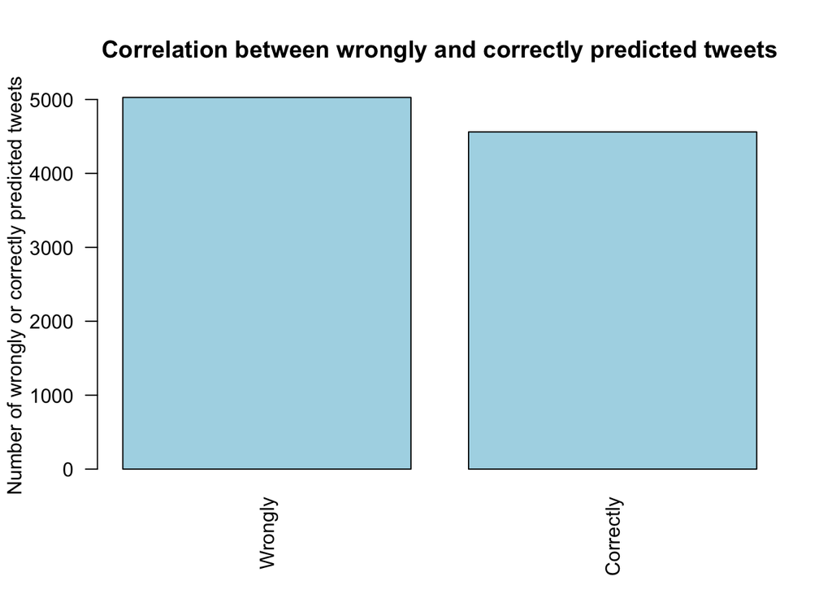

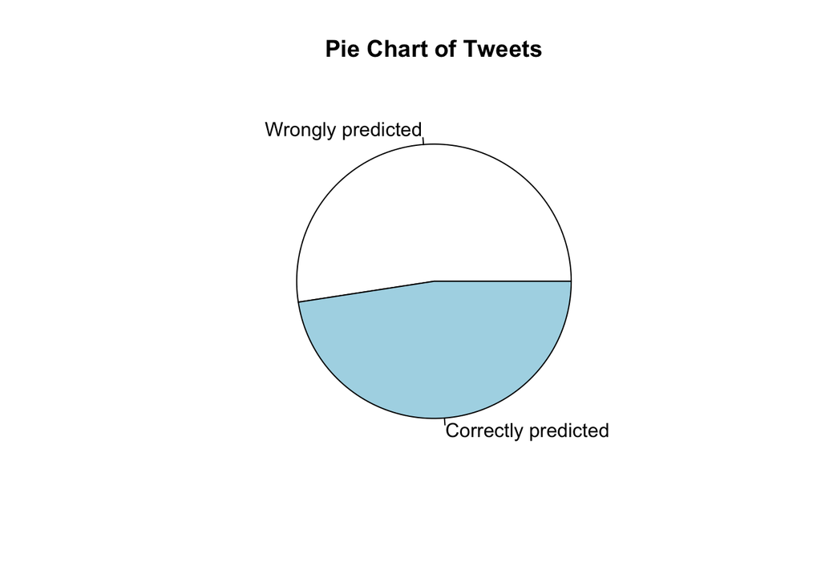

```
## [1] 0.4756492
```

```r
model$count_predict()
model$score()
```

## Measure effectiveness of your classifier

- Note that accuracy is not always a good metric for your classifier. Look at precision and recall curves, F1 score metric.
- Visualize them.
- Show failure cases.

## Conclusions:

- Describe the method implemented in general: First we process data and clear it from unnecessary characters and words. Then we calculate all necessary variables from the training set in the “fit” method, and after that use the Baye’s Formula with Laplace Smoothing to predict whether sentance is discriminatory or not.

## List pros and cons of the method:

### Pros:

The model score is not pretty high? but it guessed 47% of the results correctly.

Other pros include less training time and less training data needed for the model to function properly.

### Cons: The biggest con of this model is that we don’t take into account the ordering of words in a sentence, which can effect the result. The tweets is not such a good date to predict because in most cases some words from tweets is not found and it influence the probability.

## Add a few sencences about your implementation of the classifier:

We determine if a sentence is discriminatory or not by comparing the probability of it being discriminatory and it being neutral in the predict method.

## Describe your results:

As the result, we wrote a working model for determining discriminatory sentences based on the dataset of more than 20000 tweets with a score of 47%.